# HW3

Denys Osmak

2024-02-03

## Github: https://github.com/DenysUkr/SDS-315-GitHub-Repo/tree/a410f6483825c271cfc49fef05ca95bc8c0614c6/Homework/HW%203

# Problem 1:

## A) What creatinine clearance rate should we expect for a 55-year-old? Explain briefly (one or two sentences+ equations) how you determined this.

Using the formula
$$y = 172.283 - 1.085x$$
where y represents the creatine rate and x represents the age. We can plug in 55 for the x and determine that a 55 year old’s kidney should produce 112.6 mL of creatine per minute.

## B) How does creatinine clearance rate change with age? (This should be a single number whose units are ml/minute per year.) Explain briefly (one or two sentences) how you determined this

Using the formula
$$y = 172.283 - 1.085x$$
where y represents the creatine rate and x represents the age. We can see that the creating clearance rate decreases by 1.085 mL/min per year.

## C) Whose creatinine clearance rate is healthier (higher) for their age: a 40-year-old with a rate of 135, or a 60-year-old with a rate of 112? Explain briefly (a few sentences + equations) how you determined this.

By pluging in our formula, we predict that the 40 year old will have a creatine clearance rate of 128.883, while his actual rate is 135, meaning that his rate is 6.117 above normal. While we can predict that a 60 year old will have a clearance rate of 107.183, while his actual rate is 112, meaning that his rate is 4.817 above normal. Since the 40 year old’s clearance rate residual is higher then the 60 year old’s, it means he is healthier for this age.

# Problem 2

## What is “beta” in financial world?

A beta value in the financial world means how closely related the stock is to the overall stock market performance, or how much of the risk comes from the market volatility (also called systematic risk). The larger the beta value the larger the systematic risk is. The beta number ranges from 0 - 1. 1 meaning for every point the market goes up or down, so does this individual stock. While a value of 0 means that the individual stock does not respond to the stock market at all, no matter if it goes up or down. There are also a few other occasions where the beta value is over 1 and a negative value. If the beta is over 1, that means for every 1 point the market goes up the individual stock outproduces the market. While a negative beta value means an inverse correlation to market, meaning if the market goes down this individual stock goes up.

## Table

```
##
##
## |Tinteker |Intercept |Slope   |RSquared |
## |:--------|:---------|:-------|:--------|
## |APPL     |0.00076   |0.01254 |0.01336  |
## |GOOG     |0.00016   |0.65040 |0.64830  |
## |MRK      |0.00056   |0.67782 |0.48370  |
## |JNJ      |0.00046   |0.74121 |0.50194  |
## |WMT      |0.00026   |0.54978 |0.28532  |
## |TGT      |0.00011   |0.35029 |0.24788  |
```

## Systematic risk of the stocks

Apple has the lowest systematic risk, with the Beta value of 0.013 while the Johnson & Johnson has the highest systematic risk with the Beta value of 0.741

# Problem 3

## 1. An estimated growth rate and doubling time for Italy.

Our estimated growth rate for Ovid death rate in Italy is 18.321%, meaning that by using the rule of 70
$$70/18.321 = 3.82$$
, meaning that the Covid death toll will double every 4 days during the begging of this epidemic.

## 3. A line graph showing reported daily deaths over time

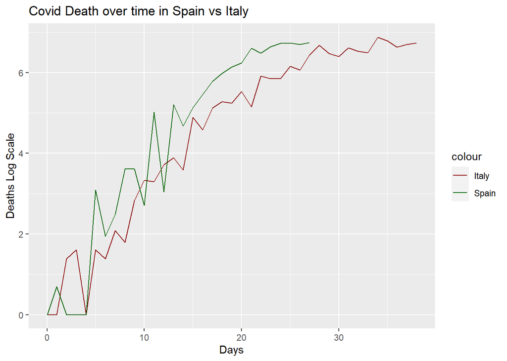

# Problem 4

In light of the data, what is the estimated price elasticity of demand for milk? Briefly describe what you did no more than a few sentences, together with your estimate.

For every 1% the price increases the sales of milk drop by 1.619%. Because the demand for the good goes down with the price increase this makes milk an elastic good.